# Rapport R Markdown Earthworms

03/05/24

Premier bloc de code : importation des librairies.

```r
library(dplyr)
```

```r
library(ggplot2)
library(tidytext)
library(tm)
library(knitr)
library(SemNetCleaner)
data("stop_words")
custom_stop_words <- tibble(word = c("plot","wild","slug","manipulation","apple"),
                                      lexicon = c("custom"))
```

Deuxième bloc de code : définition des variables.

```r
#-----------------------------
earthworms <- read.csv("~/Documents/GitHub/EarthwormsMetanalysis/ExtractionBiblio/metaanalyse_csv_final.csv")
abstracts<-c()
#---------------------
names(earthworms)
```

```
##  [1] "Title"                "First.author"         "Last.author"
##  [4] "Abstract"             "Journal"              "Language"
##  [7] "Year"                 "Month"                "First.Author.Country"
## [10] "Last.Author.Country"  "DOI"                  "DOI.URL"
## [13] "DOI.MA"               "Country.study"        "Location."
## [16] "Keywords"             "Keywords.MA"
```

```r
n = nrow(earthworms)
```

Troisième bloc de code: ajout d’une colonne “aboutEarthworms”.

```r
earthworms <- earthworms %>% mutate(aboutEarthworms = rep(TRUE,n))
```

Quatrième bloc de code: Construction de la liste des abstracts.

```r
abstracts=earthworms$Abstract
```

Cinquième bloc de code : Construction d’un dataframe de tokens.

```r
 # Unnest tokens for the current abstract
unnested_tokens <- tibble(abstracts) %>%
unnest_tokens(word, abstracts)
# Append the unnested tokens to the list
unnested_tokens<-unnested_tokens%>%anti_join(stop_words)
unnested_tokens<-unnested_tokens %>% rowwise() %>% mutate(word = singularize(word))
```

Analyse du dataframe: trouver les mots les plus communs dans les quatre MA confondues.

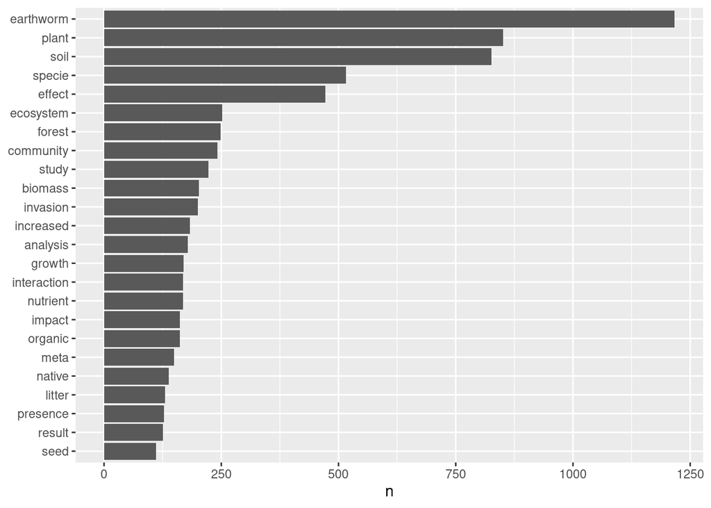

```r
ordre=unnested_tokens %>%
     count(word, sort = TRUE) %>%
     filter(n > 100) %>%
     mutate(word = reorder(word, n,decreasing=TRUE))

 ordre$word = factor(ordre$word,levels=rev(levels(ordre$word)))
 ggplot(ordre,aes(n, word)) +
     geom_col() +
     labs(y = NULL)
```

# Création de subsets correspondant aux 4 MA individuellement, afin de pouvoir les comparer entre elles.

## Import subset MA1:

```r
abstracts1<-c()
MA1 <- read.csv("~/Documents/GitHub/EarthwormsMetanalysis/ExtractionBiblio/subset_MA1.csv")
nMA1 <- nrow(MA1)
abstracts1<-MA1$Abstract
unnested_tokens1 <- tibble(abstracts1) %>%
unnest_tokens(word, abstracts1)
unnested_tokens1<-unnested_tokens1 %>% anti_join(stop_words)
unnested_tokens1<-unnested_tokens1 %>% rowwise() %>% mutate(word = singularize(word))
```

## Import subset MA2:

```r
abstracts2<-c()
MA2 <- read.csv("~/Documents/GitHub/EarthwormsMetanalysis/ExtractionBiblio/subset_MA2.csv")
nMA2 <- nrow(MA2)
abstracts2<-MA2$Abstract
unnested_tokens2 <- tibble(abstracts2) %>%
unnest_tokens(word, abstracts2)
unnested_tokens2<-unnested_tokens2 %>% anti_join(stop_words)
unnested_tokens2<-unnested_tokens2 %>% rowwise() %>% mutate(word = singularize(word))
```

## Import subset MA3:

```r
abstracts3<-c()
MA3 <- read.csv("~/Documents/GitHub/EarthwormsMetanalysis/ExtractionBiblio/subset_MA3.csv")
nMA3 <- nrow(MA3)
abstracts3<-MA3$Abstract
unnested_tokens3 <- tibble(abstracts3) %>%
unnest_tokens(word, abstracts3)
unnested_tokens3<-unnested_tokens3 %>% anti_join(stop_words)
unnested_tokens3<-unnested_tokens3 %>% rowwise() %>% mutate(word = singularize(word))
```

## Import subset MA4:

```r
abstracts4<-c()
MA4 <- read.csv("~/Documents/GitHub/EarthwormsMetanalysis/ExtractionBiblio/subset_MA4.csv")
nMA4 <- nrow(MA4)
abstracts4<-MA4$Abstract
unnested_tokens4 <- tibble(abstracts4) %>%
unnest_tokens(word, abstracts4)
unnested_tokens4<-unnested_tokens4 %>% anti_join(stop_words)
unnested_tokens4<-unnested_tokens4 %>% rowwise() %>% mutate(word = singularize(word))
```

# Création des quatre plots:

## Plot MA1 :

```r
ordre1=unnested_tokens1 %>%
     count(word, sort = TRUE) %>%
     filter(n > 25) %>%
     mutate(word = reorder(word, n,decreasing=TRUE))

 ordre1$word = factor(ordre1$word,levels=rev(levels(ordre1$word)))
 plot1<-ggplot(ordre1,aes(n, word)) +
     geom_col() +
     labs(y = NULL)
```

## Plot MA2 :

```r
ordre2=unnested_tokens2 %>%
     count(word, sort = TRUE) %>%
     filter(n > 25) %>%
     mutate(word = reorder(word, n,decreasing=TRUE))

 ordre2$word = factor(ordre2$word,levels=rev(levels(ordre2$word)))
 plot2<-ggplot(ordre2,aes(n, word)) +
     geom_col() +
     labs(y = NULL)
```

## Plot MA3 :

```r
ordre3=unnested_tokens3 %>%
     count(word, sort = TRUE) %>%
     filter(n > 25) %>%
     mutate(word = reorder(word, n,decreasing=TRUE))

 ordre3$word = factor(ordre3$word,levels=rev(levels(ordre3$word)))
 plot3<-ggplot(ordre3,aes(n, word)) +
     geom_col() +
     labs(y = NULL)
```

## Plot MA4:

```r
ordre4=unnested_tokens4 %>%
     count(word, sort = TRUE) %>%
     filter(n > 25) %>%
     mutate(word = reorder(word, n,decreasing=TRUE))

 ordre4$word = factor(ordre4$word,levels=rev(levels(ordre4$word)))
 plot4<-ggplot(ordre4,aes(n, word)) +
     geom_col() +
     labs(y = NULL)
```

# Comparaison des quatre MA:

Quels sont les mots les plus communs dans chacunes des MA?

```r
library(egg)
```

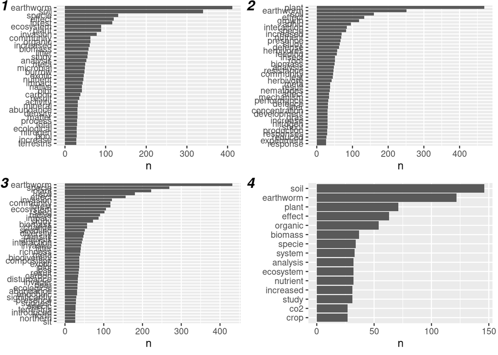

```r
ggarrange(plot1,plot2,plot3,plot4,widths = c(5,5),labels = c("1","2","3","4"))
```

# DataFrame pour comparer les fréquences des 4 MA:

```r
library(tidyr)

frequency1 <- bind_rows(mutate(unnested_tokens1, author = "MA1"),
                       mutate(unnested_tokens2, author = "MA2"),
                       mutate(unnested_tokens3, author = "MA3"),
                       mutate(unnested_tokens4, author = "MA4"))%>%
  mutate(word = stringr::str_extract(word, "[a-z']+")) %>%
  count(author, word) %>%
  group_by(author) %>%
  mutate(proportion = n / sum(n)) %>%
  select(-n) %>%
  pivot_wider(names_from = author, values_from = proportion) %>%
  pivot_longer(cols=c('MA2','MA3','MA4'),
               names_to = "author", values_to = "proportion")
```

```r
frequency2 <- bind_rows(mutate(unnested_tokens1, author = "MA1"),
                       mutate(unnested_tokens2, author = "MA2"),
                       mutate(unnested_tokens3, author = "MA3"),
                       mutate(unnested_tokens4, author = "MA4"))%>%
  mutate(word = stringr::str_extract(word, "[a-z']+")) %>%
  count(author, word) %>%
  group_by(author) %>%
  mutate(proportion = n / sum(n)) %>%
  select(-n) %>%
  pivot_wider(names_from = author, values_from = proportion) %>%
  pivot_longer(cols=c('MA1','MA3','MA4'),
               names_to = "author", values_to = "proportion")
```

```r
frequency3 <- bind_rows(mutate(unnested_tokens1, author = "MA1"),
                       mutate(unnested_tokens2, author = "MA2"),
                       mutate(unnested_tokens3, author = "MA3"),
                       mutate(unnested_tokens4, author = "MA4"))%>%
  mutate(word = stringr::str_extract(word, "[a-z']+")) %>%
  count(author, word) %>%
  group_by(author) %>%
  mutate(proportion = n / sum(n)) %>%
  select(-n) %>%
  pivot_wider(names_from = author, values_from = proportion) %>%
  pivot_longer(cols=c('MA1','MA2','MA4'),
               names_to = "author", values_to = "proportion")
```

# Graphe de comparaison des fréquences:

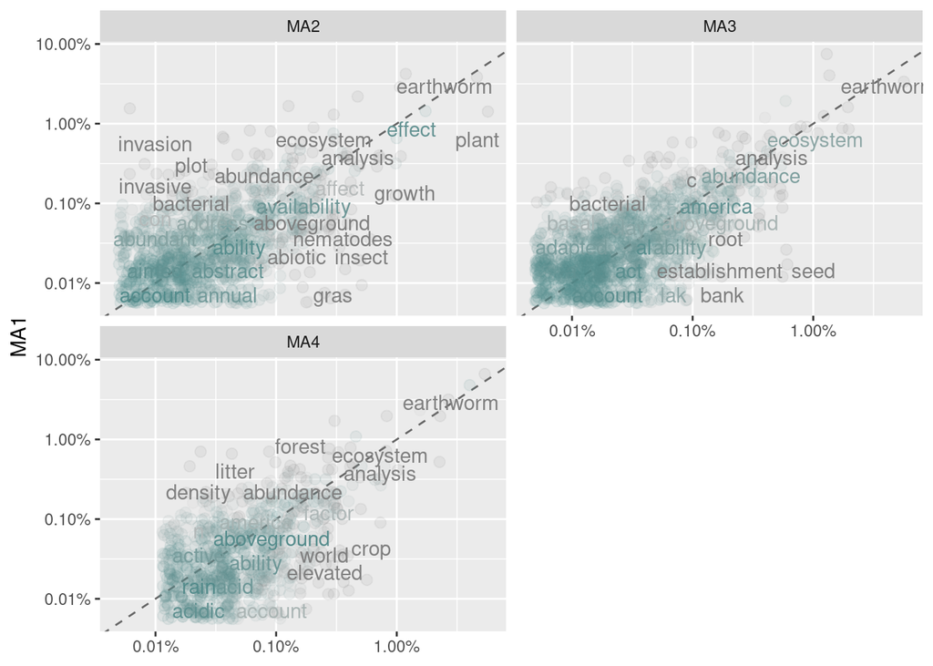

```r
library(scales)

# expect a warning about rows with missing values being removed
ggplot(frequency1, aes(x = proportion, y = `MA1`,
                      color = abs(`MA1` - proportion))) +
  geom_abline(color = "gray40", lty = 2) +
  geom_jitter(alpha = 0.1, size = 2.5, width = 0.3, height = 0.3) +
  geom_text(aes(label = word), check_overlap = TRUE, vjust = 1.5) +
  scale_x_log10(labels = percent_format()) +
  scale_y_log10(labels = percent_format()) +
  scale_color_gradient(limits = c(0, 0.001),
                       low = "darkslategray4", high = "gray75") +
  facet_wrap(~author, ncol = 2) +
  theme(legend.position="none") +
  labs(y = "MA1", x = NULL)
```

Quelques mots sont au pluriel, ce qui signifie que la fonction “singularize” n’a pas fonctionné correctement (des mots tels que “herbivores” ou “abundances”.)

## MA1 vs MA2 :

- Les mots proches de la ligne dans ces graphiques ont des fréquences similaires dans les deux ensembles de textes, soit, dans l’ordre croissant: “account”, “action”, “abundance”, “fungal”, “ability”, “vary”, “addition”, “animal”, “chemical”, “approach”, “control”, “experiment”, “impact”, “activity”, “liter”, “result”, **“analysis”, “specie”, “effect”, “earthworm”**.
- Les mots **“fraction”, “invasion”, “native” et “burrow”** sont plus fréquents dans la MA1 que dans la MA2, tandis que les mots **“grass”, “herbivore” et “plant”** sont plus fréquents dans la MA2 que de la MA1.

## MA1 vs MA3 :

- Les mots proches de la ligne dans ces graphiques ont des fréquences similaires dans les deux ensembles de textes, soit, dans l’ordre croissant: “acquisition”, “accompany”, “abiotic”, “mass”, “addition”, “common”, “fauna”, “north”, America”, “due”, “affect”,“carbon”, “analysis”, “abundance”, “study”, “impact”, “ecosystem”, “community”, “effect”, **“plant”, “specie”, “soil”, “earthworm”**.
- Les mots **“caliginosa”, “macroaggregate”, “bacterial” et “volume”** sont plus fréquents dans la MA1 que dans la MA3, tandis que les mots **“bank”, “invader”, “seedling” et “seed”** sont plus fréquents dans la MA3 que de la MA1.

## MA1 vs MA4 :

- Les mots proches de la ligne dans ces graphiques ont des fréquences similaires dans les deux ensembles de textes, soit, dans l’ordre croissant: “action”, “analytic”, “abiotic”, “arable”, “affected”, “cover”, “abovground”, “addition”, “change”, “role”, “influence”, “affect”, “activity”, “increase”, “impact”, “result”, “community”, “analysis”, “ecosystem”, **“species”, “organic”, “plant”, “effect”,“earthworm”**.
- Les mots **“exotic”,“burrow”,“density” et “habitat”** sont plus fréquents dans la MA1 que dans la MA4, tandis que les mots **“atmosferic”, “tissue” et “crop”** sont plus fréquents dans la MA4 que de la MA1.

## Analyse globale:

- Dans cette configuration, la MA1 et la MA3 semblent être les plus similaires en termes de fréquences de mots (nuage de points davantage resserré autour de la droite.)
- Dans cette configuration, la MA1 et la MA2 semblent être les moins similaires en termes de fréquences de mots (nuage de points davantage dispersé autour de la droite.)

# Tests de corrélation:

Quel est le degré de corrélation entre les fréquences de mots de chaque métaanalyse ?

## MA2 VS MA1

```r
cor.test(data = frequency1[frequency1$author == "MA2",],
         ~ proportion + `MA1`)
```

```
##
##  Pearson's product-moment correlation
##
## data:  proportion and MA1
## t = 29.649, df = 1070, p-value < 2.2e-16
## alternative hypothesis: true correlation is not equal to 0
## 95 percent confidence interval:
##  0.6373264 0.7031734
## sample estimates:
##       cor
## 0.6715737
```

## MA3 VS MA1

```r
cor.test(data = frequency1[frequency1$author == "MA3",],
         ~ proportion + `MA1`)
```

```
##
##  Pearson's product-moment correlation
##
## data:  proportion and MA1
## t = 69.076, df = 1348, p-value < 2.2e-16
## alternative hypothesis: true correlation is not equal to 0
## 95 percent confidence interval:
##  0.8706841 0.8942412
## sample estimates:
##       cor
## 0.8830176
```

## MA4 VS MA1

```r
cor.test(data = frequency1[frequency1$author == "MA4",],
         ~ proportion + `MA1`)
```

```
##
##  Pearson's product-moment correlation
##
## data:  proportion and MA1
## t = 57.751, df = 814, p-value < 2.2e-16
## alternative hypothesis: true correlation is not equal to 0
## 95 percent confidence interval:
##  0.8822108 0.9092417
## sample estimates:
##       cor
## 0.8965579
```

## MA3 VS MA2

```r
cor.test(data = frequency2[frequency2$author == "MA3",],
         ~ proportion + `MA2`)
```

```
##
##  Pearson's product-moment correlation
##
## data:  proportion and MA2
## t = 34.38, df = 1046, p-value < 2.2e-16
## alternative hypothesis: true correlation is not equal to 0
## 95 percent confidence interval:
##  0.6986211 0.7555926
## sample estimates:
##       cor
## 0.7283633
```

## MA4 VS MA2

```r
cor.test(data = frequency2[frequency2$author == "MA4",],
         ~ proportion + `MA2`)
```

```
##
##  Pearson's product-moment correlation
##
## data:  proportion and MA2
## t = 34.586, df = 895, p-value < 2.2e-16
## alternative hypothesis: true correlation is not equal to 0
## 95 percent confidence interval:
##  0.7268434 0.7830104
## sample estimates:
##       cor
## 0.7563172
```

## MA4 VS MA3

```r
cor.test(data = frequency3[frequency3$author == "MA4",],
         ~ proportion + `MA3`)
```

```
##
##  Pearson's product-moment correlation
##
## data:  proportion and MA3
## t = 35.163, df = 804, p-value < 2.2e-16
## alternative hypothesis: true correlation is not equal to 0
## 95 percent confidence interval:
##  0.7496838 0.8042616
## sample estimates:
##       cor
## 0.7784396
```

## Tableau récapitulatif :

|  | MA1 | MA2 | MA3 | MA4 |
| --- | --- | --- | --- | --- |
| MA1 | - | 0.671 | 0.883 | 0.897 |
| MA2 |  | - | 0.728 | 0.756 |
| MA3 |  |  | - | 0.778 |
| MA4 |  |  |  | - |

MA1: “Soil chemistry turned upside down: a meta-analysis of invasive earthworm effects on soil chemical properties”  
MA2: “Earthworms affect plant growth and resistance against herbivores: A meta-analysis”  
MA3: “The unseen invaders: introduced earthworms as drivers of change in plant communities in North American forests (a meta-analysis)”  
MA4: “Earthworms increase plant production: a meta-analysis”

D’après le tableau ci-dessus, on peut voir que le choix de mots est le plus corrélé (correlation de Pearson) entre la MA1 et la MA4 (r²=0.897), tandis que le choix de mots est le moins corrélé (corrélation de Pearson) entre la MA1 et la MA2 (r²=0.671).

# Analyse de sentiments entre les 4 métaanalyses:

## Premiers graphiques.

On commence par construire des Tibbles contenant chaque mot exprimant un sentiment positif ou négatif (colonne *word*), puis on compte le nombre d’occurence de chaque mot (colonne *n*).

```r
library(tidytext)
bing<-get_sentiments("bing")

senti1<-unnested_tokens1 %>%
  inner_join(bing) %>%
  count(word, sort = TRUE)

senti2<-unnested_tokens2 %>%
  inner_join(bing) %>%
  count(word, sort = TRUE)

senti3<-unnested_tokens3 %>%
  inner_join(bing) %>%
  count(word, sort = TRUE)

senti4<-unnested_tokens4 %>%
  inner_join(bing) %>%
  count(word, sort = TRUE)
```

On ne conserve que les dix premières valeurs et les dix dernières valeurs, afin de pouvoir produire des graphiques plus lisibles ne conservant que les valeurs extrêmes.

```r
library(tidyr)
MA1_senti <- senti1 %>%
  inner_join(get_sentiments("bing")) %>%
  pivot_wider(names_from = sentiment, values_from = n, values_fill = 0) %>%
  mutate(sentiment = positive - negative)
sub1_MA1_senti<-MA1_senti %>%
    arrange(sentiment) %>%
    slice(1:10)
sub2_MA1_senti<-MA1_senti %>%
    arrange(desc(sentiment)) %>%
    slice(1:10)
sub_MA1_senti<-bind_rows(sub1_MA1_senti, sub2_MA1_senti)
```

On réalise un premier barplot, en associant à chaque mot positif la valeur de sentiment +1, et à chaque mot négatif la valeur de sentiment -1. On représente ensuite cela graphiquement chaque mot en abscisse et la somme de ses indices (dont la valeur dépend de sa connotation et du nombre d’occurences) en ordonnées. On peut noter que certains mots scientifiques (comme “plot” ou “manipulation”) se sont ici vu attribués une connotation négative, car le dictionnaire de “stop words” n’est pas spécifiquement adapté au vocabulaire scientifique.

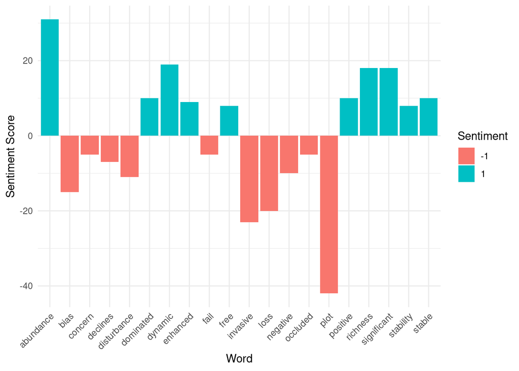

```r
ggplot(sub_MA1_senti, aes(x = word, y = sentiment, fill = factor(sign(sentiment)))) +
  geom_bar(stat = "identity") +
  labs(x = "Word", y = "Sentiment Score", fill = "Sentiment") +
  theme_minimal() +
  theme(axis.text.x = element_text(angle = 45, hjust = 1))
```

On répète le processus pour comparer les métaanalyses 1,2,3 et 4.

```r
library(tidyr)
library(ggplot2)

plot_sentiment_subset <- function(senti) {
  MA_senti <- senti %>%
    inner_join(get_sentiments("bing")) %>%
    pivot_wider(names_from = sentiment, values_from = n, values_fill = 0) %>%
    mutate(sentiment = positive - negative)

  sub1_MA_senti <- MA_senti %>%
    anti_join(custom_stop_words, by = c("word")) %>%
    arrange(sentiment) %>%
    slice(1:5)

  sub2_MA_senti <- MA_senti %>%
    anti_join(custom_stop_words, by = c("word")) %>%
    arrange(desc(sentiment)) %>%
    slice(1:5)

  sub_MA_senti <- bind_rows(sub1_MA_senti, sub2_MA_senti)

  ggplot(sub_MA_senti, aes(x = word, y = sentiment, fill = factor(sign(sentiment)))) +
    geom_bar(stat = "identity") +
    labs(x = "Word", y = "Sentiment Score", fill = "Sentiment") +
    theme_minimal() +
    theme(axis.text.x = element_text(angle = 45, hjust = 1))
}

plot_senti1<-plot_sentiment_subset(senti1)
plot_senti2<-plot_sentiment_subset(senti2)
plot_senti3<-plot_sentiment_subset(senti3)
plot_senti4<-plot_sentiment_subset(senti4)
```

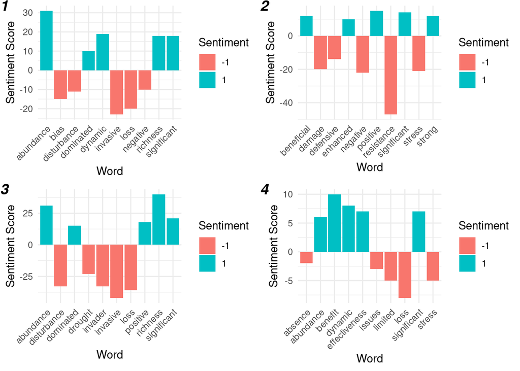

```r
library(egg)
ggarrange(plot_senti1,plot_senti2,plot_senti3,plot_senti4,widths = c(2,2),labels = c("1","2","3","4"))
```

On peut enfin constater que le mot *“resistance”* est le mots le plus représenté dans le subset 2 (> 40 occurences), résultat qui ne semble pas particulièrement surprenant compte tenu du fait que cette métaanalyse s’intéresse plus spécifiquement aux mécanismes de résistance contre les herbivores. D’ailleurs, il convient aussi de noter que malgré sa comptabilisation négative dans le graphique, dans ce contexte scientifique précis, il semble plus raisonnable de le considérer comme un mot à valence positive.

MA1: “Soil chemistry turned upside down: a meta-analysis of invasive earthworm effects on soil chemical properties”  
MA2: “Earthworms affect plant growth and resistance against herbivores: A meta-analysis”  
MA3: “The unseen invaders: introduced earthworms as drivers of change in plant communities in North American forests (a meta-analysis)”  
MA4: “Earthworms increase plant production: a meta-analysis”

## Contribution de chaque terme au score final de sentiment.

```r
bing_word_counts1 <- unnested_tokens1 %>%
  inner_join(get_sentiments("bing")) %>%
  count(word, sentiment, sort = TRUE) %>%
  ungroup()
bing_word_counts2 <- unnested_tokens2 %>%
  inner_join(get_sentiments("bing")) %>%
  count(word, sentiment, sort = TRUE) %>%
  ungroup()
bing_word_counts3 <- unnested_tokens3 %>%
  inner_join(get_sentiments("bing")) %>%
  count(word, sentiment, sort = TRUE) %>%
  ungroup()
bing_word_counts4 <- unnested_tokens4 %>%
  inner_join(get_sentiments("bing")) %>%
  count(word, sentiment, sort = TRUE) %>%
  ungroup()
```

```r
contrib1<-bing_word_counts1 %>%
  anti_join(custom_stop_words, by = c("word")) %>%
  group_by(sentiment) %>%
  slice_max(n, n = 10) %>%
  ungroup() %>%
  mutate(word = reorder(word, n)) %>%
  ggplot(aes(n, word, fill = sentiment)) +
  geom_col(show.legend = FALSE) +
  facet_wrap(~sentiment, scales = "free_y") +
  labs(x = "Contribution to sentiment",
       y = NULL)

contrib2<-bing_word_counts2 %>%
  anti_join(custom_stop_words, by = c("word")) %>%
  group_by(sentiment) %>%
  slice_max(n, n = 10) %>%
  ungroup() %>%
  mutate(word = reorder(word, n)) %>%
  ggplot(aes(n, word, fill = sentiment)) +
  geom_col(show.legend = FALSE) +
  facet_wrap(~sentiment, scales = "free_y") +
  labs(x = "Contribution to sentiment",
       y = NULL)

contrib3<-bing_word_counts3 %>%
  anti_join(custom_stop_words, by = c("word")) %>%
  group_by(sentiment) %>%
  slice_max(n, n = 10) %>%
  ungroup() %>%
  mutate(word = reorder(word, n)) %>%
  ggplot(aes(n, word, fill = sentiment)) +
  geom_col(show.legend = FALSE) +
  facet_wrap(~sentiment, scales = "free_y") +
  labs(x = "Contribution to sentiment",
       y = NULL)

contrib4<-bing_word_counts4 %>%
  anti_join(custom_stop_words, by = c("word")) %>%
  group_by(sentiment) %>%
  slice_max(n, n = 10) %>%
  ungroup() %>%
  mutate(word = reorder(word, n)) %>%
  ggplot(aes(n, word, fill = sentiment)) +
  geom_col(show.legend = FALSE) +
  facet_wrap(~sentiment, scales = "free_y") +
  labs(x = "Contribution to sentiment",
       y = NULL)
```

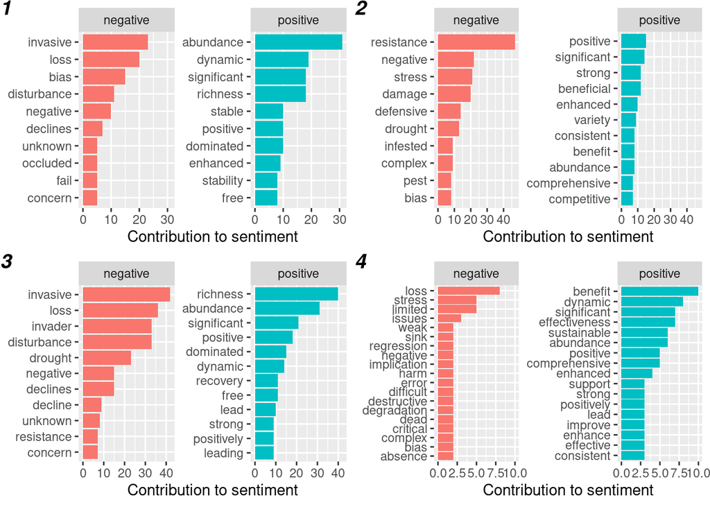

```r
library(egg)
ggarrange(contrib1,contrib2,contrib3,contrib4,widths = c(2,2),labels = c("1","2","3","4"))
```

Par ailleues, de même que précédemment, l’échelle du graphique de la MA4 en abscisse est quatre fois plus petite, ce qui laisse entendre, une fois de plus, que le subset 4 est plus réduit que les autres.

Les trois mots positifs les plus courants sont:  
* *MA1:* “abundance”, dynamic”, “significant”.  
* *MA2:* “positive”, “significant”, “strong”.  
* *MA3:* “richness”, “abundance”, “significant”.  
* *MA4:* “benefit”, “dynamic”, “significant”.  
On remarque tout d’abord que le mot *“significant”* fait partie des trois mots qui a le plus contribué au sentiment dans tous les subsets. Le contexte semble nécessaire pour savoir s’il est employé pour décrire un phénomène positif ou négatif.  
Par ailleurs, le mot *“abundance”* n’est dans les 3 premiers que dans les subsets 1 et 3, ce qui semble cohérent avec les résultats précédents: les MA1 et 3 semblent plus proches entre elles qu’elles ne le sont des deux autres. Pour ce qui est des MA2 et 4, ce seul résultat ne suffit pas à indiquer une proximité particulière entre les deux textes.

Cependant, il serait peut-être nécessaire d’étudier des unités textuelles plus larges, comme par exemple les phrases, pour éviter au maximum le risque de contresens.

# Wordclouds

## Wordcloud MA1

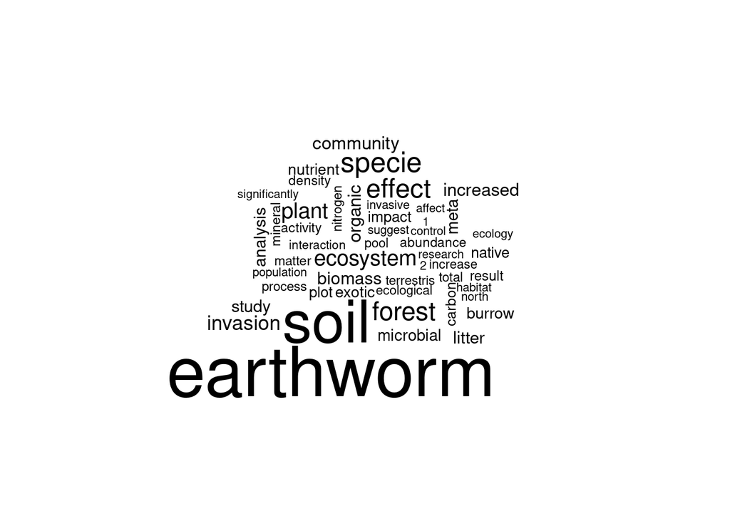

```r
library(wordcloud)
library(dplyr)

unnested_tokens1 %>%
  anti_join(stop_words) %>%
  count(word) %>%
  with(wordcloud(word, n, max.words = 50))
```

```r
cloud1 <- recordPlot()
```

## Wordcloud MA2

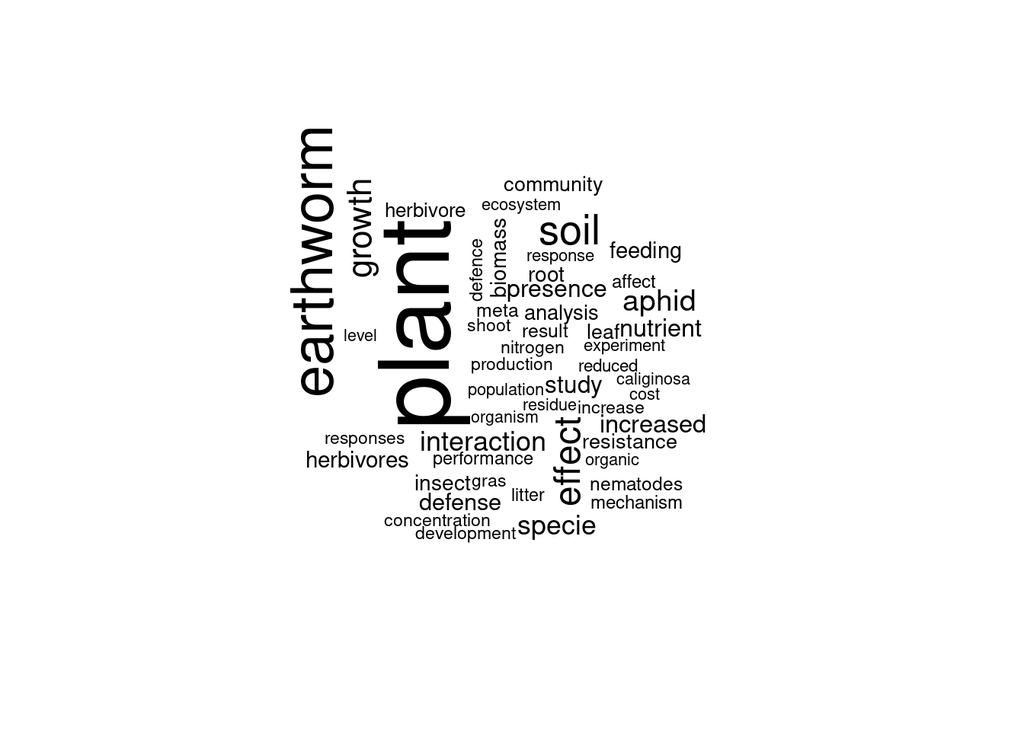

```r
unnested_tokens2 %>%
  anti_join(stop_words) %>%
  count(word) %>%
  with(wordcloud(word, n, max.words = 50))
```

```r
cloud2 <- recordPlot()
```

## Wordcloud MA3

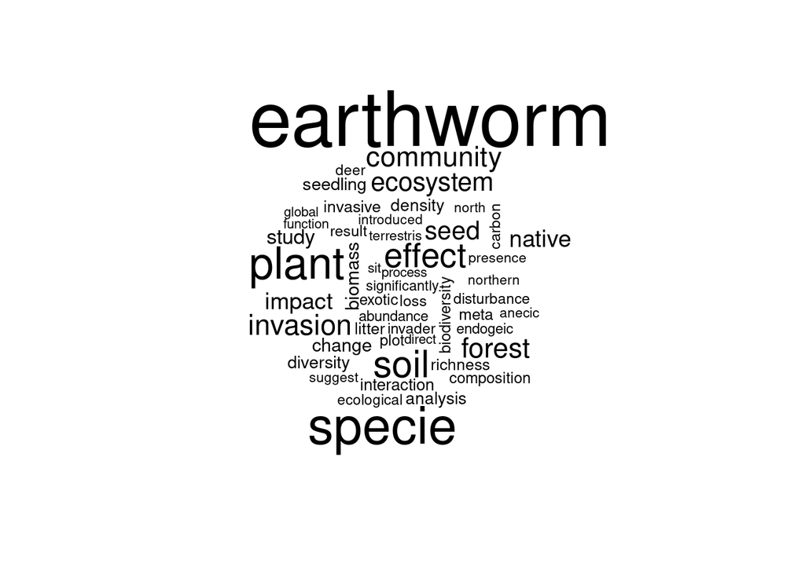

```r
unnested_tokens3 %>%
  anti_join(stop_words) %>%
  count(word) %>%
  with(wordcloud(word, n, max.words = 50))
```

```r
cloud3 <- recordPlot()
```

## Wordcloud MA4

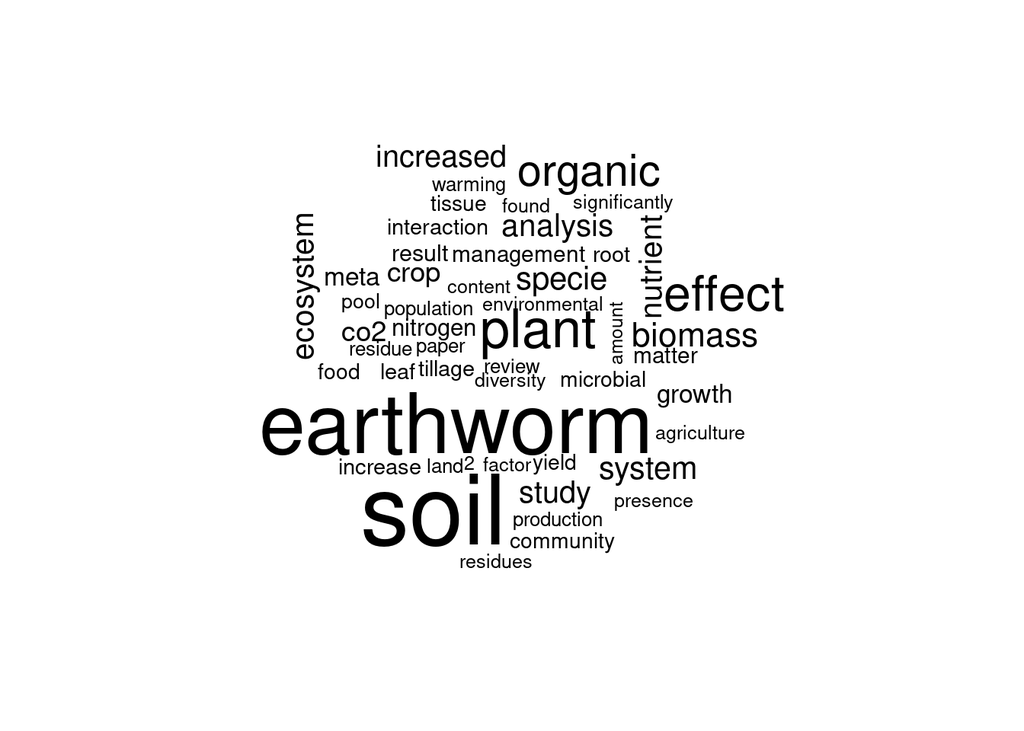

```r
unnested_tokens4 %>%
  anti_join(stop_words) %>%
  count(word) %>%
  with(wordcloud(word, n, max.words = 50))
```

```r
cloud4 <- recordPlot()
```

# Wordcloud: coloration en fonction de la valence des mots.

## Wordcloud MA1

```r
library(reshape2)
```

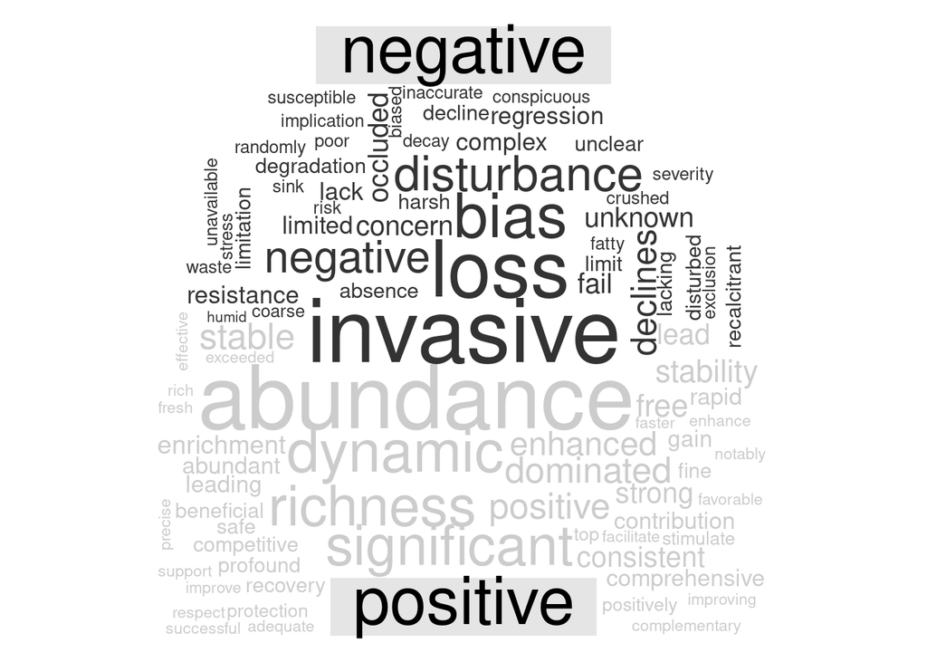

```r
unnested_tokens1 %>%
  anti_join(custom_stop_words, by = c("word")) %>%
  inner_join(get_sentiments("bing")) %>%
  count(word, sentiment, sort = TRUE) %>%
  acast(word ~ sentiment, value.var = "n", fill = 0) %>%
  comparison.cloud(colors = c("gray20", "gray80"),
                   max.words = 100)
```

```r
cloud_senti1<-recordPlot()
```

## Wordcloud MA2

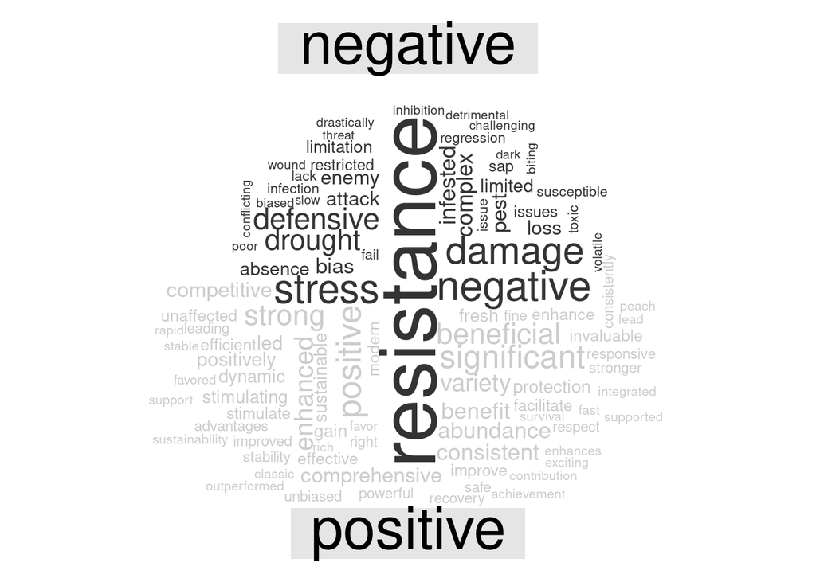

```r
unnested_tokens2 %>%
  anti_join(custom_stop_words, by = c("word")) %>%
  inner_join(get_sentiments("bing")) %>%
  count(word, sentiment, sort = TRUE) %>%
  acast(word ~ sentiment, value.var = "n", fill = 0) %>%
  comparison.cloud(colors = c("gray20", "gray80"),
                   max.words = 100)
```

```r
cloud_senti2<-recordPlot()
```

## Wordcloud MA3

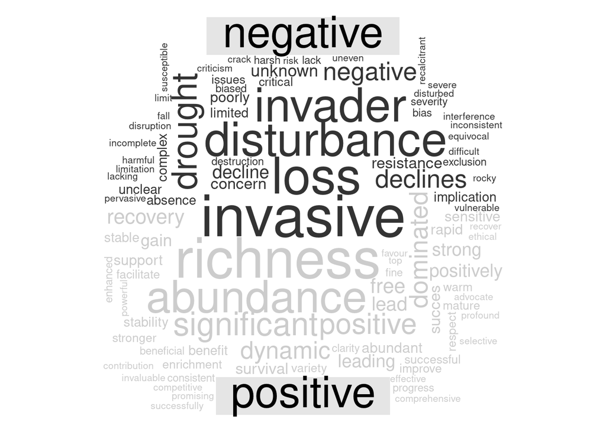

```r
unnested_tokens3 %>%
  anti_join(custom_stop_words, by = c("word")) %>%
  inner_join(get_sentiments("bing")) %>%
  count(word, sentiment, sort = TRUE) %>%
  acast(word ~ sentiment, value.var = "n", fill = 0) %>%
  comparison.cloud(colors = c("gray20", "gray80"),
                   max.words = 100)
```

```r
cloud_senti3<-recordPlot()
```

## Wordcloud MA4

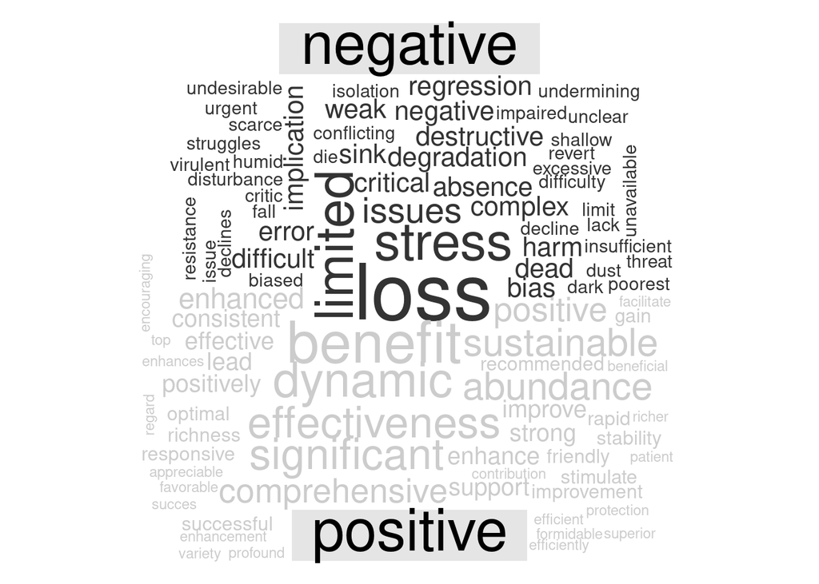

```r
unnested_tokens4 %>%
  anti_join(custom_stop_words, by = c("word")) %>%
  inner_join(get_sentiments("bing")) %>%
  count(word, sentiment, sort = TRUE) %>%
  acast(word ~ sentiment, value.var = "n", fill = 0) %>%
  comparison.cloud(colors = c("gray20", "gray80"),
                   max.words = 100)
```

```r
cloud_senti4<-recordPlot()
```

```r
sentences1 <- tibble(text = abstracts1) %>%
  unnest_tokens(sentence, text, token = "sentences")
sentences2 <- tibble(text = abstracts2) %>%
  unnest_tokens(sentence, text, token = "sentences")
sentences3 <- tibble(text = abstracts3) %>%
  unnest_tokens(sentence, text, token = "sentences")
sentences4 <- tibble(text = abstracts4) %>%
  unnest_tokens(sentence, text, token = "sentences")
```

```r
bingnegative <- get_sentiments("bing") %>%
  filter(sentiment == "negative")

wordcounts1 <- bing_word_counts1 %>%
  group_by(word, sentiment) %>%
  summarize(words =n)
ratio1<-bing_word_counts1 %>%
  semi_join(bingnegative) %>%
  group_by(word, sentiment) %>%
  summarize(negativewords = n()) %>%
  left_join(wordcounts1, by = c("word", "sentiment")) %>%
  mutate(ratio = negativewords/words) %>%
  slice_max(ratio, n = 1) %>%
  ungroup()
```